# Relational Databases and Postgres

36-350 – Statistical Computing

Week 12 – Spring 2021

# Context

- A relational database (or RDB) is a structure for organizing information that one may think of initially as a supercharged version of a data frame. (The word “relational” does not actually indicate that relationships can exist between separate units in your database. It actually has to do with the concept of *relational algebra*, first proposed [in this paper by E. F. Codd](http://www.seas.upenn.edu/~zives/03f/cis550/codd.pdf).)
- In an RDB, the basic unit of data storage is the *table* (or *relation* or *schema*). Rows are rows, but sometimes dubbed *tuples* or *records*, and columns are sometimes dubbed *attributes*. (*Fields* are specific cells within a given row.)
- RDBs come with performance guarantees, dubbed ACID.
- When designing an RDB, a key goal is to eliminate redundancy by having many tables that are linked via *foreign keys*. For instance, if you want to construct an RDB having information about movies, actors, and studios (where, e.g., a movie is produced by a studio and stars an actor), it makes the most sense to split the information cleanly between interlinked tables.
- RDBs are commonly manipulated and queried using `SQL`: Structured Query Language.

# Postgres

- There are many implementations of `SQL` (SEE-kwule): `Oracle`, `MySQL`, `SQLite`, etc.
- In this class, we will make use of [PostgreSQL](https://www.postgresql.org/), or more simply `Postgres`. It is open source, with Mac, Windows, and Linux versions available. You should download and install it!
- `Postgres` will set up a server on your machine. When you install `Postgres`, a superuser account “postgres” will be set up, with a password specified by you. Make this a good one, i.e., not just “postgres.” (That’s because hackers like to look for lazily set up postgres accounts.)
- When you start up postgres for the first time (meaning: run the SQL Shell, or `psql`…or by typing `psql -U postgres` in a [Mac] terminal window), you will see something like this:

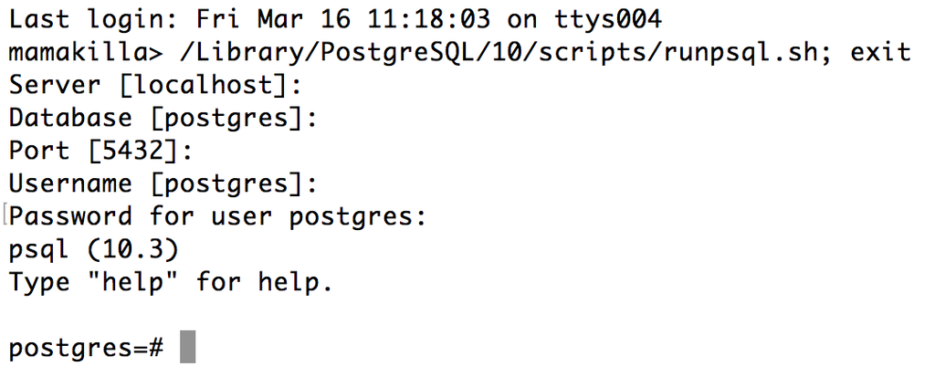

(Note that you can run code within the `pgAdmin 4` program that may have come packaged with your version of `postgres`, but I find the SQL shell to be more straightforward. Also note that the interface may differ for Windows; if you are a Windows user having issues, we will try to direct you to a Windows-using TA who may be able to help.)

- You should hit return to accept the defaults at each prompt, and provide the password at the end to get to the postgres prompt (`postgres=#`).
- If you are the only user on your machine, then it is fine to play around with SQL from within the `postgres` account. More generally, the `postgres` admin would apply the `createuser` command from within `postgres` to carve out space for you to play in.
- A good book to use as a reference for `postgres` is [this one](https://nostarch.com/practicalSQL).

# Finding Your Way Around

I’m in! How do I…

- get help? `\h` for general listing, `\h <command>` for specific command (also: Google, as always)
- list the tables I have in my database? `\d`
- read input from a `sql`-format file? `\i <path to + name of file>`
- change directory? `\cd <path to new directory>`
- get the heck out? `\q`

To list all (back)slash commands, type `\?` at the `postgres` prompt. (There are many!)

# Tables

Tables are the data frames of `SQL`. But whereas `R` has much more than just data frames, life in `SQL` revolves around tables; as I am wont to say, “Everything in `SQL` is a table.” As an example, you cannot print out the value of $\pi$ unless it’s in a table:

```
select pi();
        pi
------------------
 3.14159265358979
(1 row)
```

(Here, the value of $\pi$ is being displayed in a one-row, one-column table, with column name `pi`. Don’t worry about the `select` part for now; we’ll cover that starting next week. Do worry about the semicolon: any command in `postgres` that doesn’t start with a backslash needs to end with a semicolon. Leaving the semicolon out is possibly the Number 1 Coding Error of new `SQL` users.)

# Tables

We note the following about tables:

- **each table in a database represents a single entity**;
- each row of a table represents **one instance** of that entity;
- each column of a table must have a **name**;
- each column of a table must have a **pre-specified data type**; and
- the columns in each row must satisfy any **constraints** specified with the table is created.

# Data Types

Unlike `R`, there are *many* defined data types in `SQL`. For documentation on those defined within `postgres`, see [the postgres data type documentation page](https://www.postgresql.org/docs/10/static/datatype.html).

For our purposes, there are three categories of data types that you will utilize the most:

- characters;
- numbers; and
- dates/times.

We will look at each category over the next few slides.

Note that in addition to these there is a `boolean` type, which can take on the values `true` (or `yes` or `on` or `1`), `false` (or `no` or `off` or `0`), and `unknown`.

# Data Types: Characters

There are three data types used for handling strings:

- `char(n)`: fixed-length strings with $n$ characters, padded with blank spaces if necessary;
- `varchar(n)`: variable-length strings that can have *at most* $n$ characters, with no blank-space padding; and
- `text`: variable-length strings of arbitrary length, with no blank-space padding.

One would generally use `char(n)` only when the length of the strings is known and constant (as would be the case for, e.g., state postal code abbreviations like `PA`). Otherwise, `varchar(n)` is preferred over `text` just because it effectively puts a cap on the amount of memory taken up by a table.

# Data Types: Integers

`SQL` provides a wide variety of data types for representing integers and both fixed-point and floating-point numbers.

For integers:

| Data Type | Storage Size | Range |
| --- | --- | --- |
| `smallint` | 2 bytes | $-2^{15}$ to $2^{15}-1$ |
| `integer` | 4 bytes | $-2^{31}$ to $2^{31}-1$ |
| `bigint` | 8 bytes | $-2^{63}$ to $2^{63}-1$ |

While most programmers will default to `integer`, for most purposes `smallint` is appropriate and will reduce memory use.

There is also a special category of “auto-incrementing” integers with types `smallserial`, `serial`, and `bigserial`. These are purely positive variations on the integer types listed above, and are used to, e.g., provide unique labels for each row of a table (i.e., “keys”). We will see how `serial` is used later when we insert data into tables.

# Data Types: Fixed- and Floating-Point Numbers

The difference between fixed- and floating-point numbers is in how the computer stores them in memory, and is a topic beyond the scope of this class. Simply note that arithmetic with floating-point numbers can yield inexact results, but in the vast majority of cases the slight inexactness has no bearing on data analysis and interpretation. (In `R`, `numeric` is a floating-point data type.)

For fixed-point numbers, we have

- `numeric(precision,scale)`: the number contains at most `precision` digits overall, with `scale` digits to the right of the decimal point. For instance, `147.89` is an example of a number that can be stored as data type `numeric(5,2)`. (Note that `decimal` is an alternative name for `numeric`.) The `numeric` data type is useful when we know that a particular number will not have more than a particular number of digits (e.g., rainfall in a 24-hour period requires at most two digits to the left of the decimal point) and when we want to round off to, say, the hundredths place.

Note that there is a `money` type within `SQL` which is akin to `numeric` but fixes the number of digits to two to the right of the decimal point (and allows for symbols like `$` to be included with the numbers).

For floating-point numbers, we have

- `real`: the number is stored in 4 bytes and is precise to 6 decimal places; and
- `double precision`: the number is stored in 8 bytes and is precise to 15 decimal places.

# Data Types: Dates and Times

The common data types for dates and times include:

- `date`: specified as `YYYY-MM-DD`;
- `time`: specified as `HH:MM:SS`;
- `timestamp`: combines `date` and `time`;
- `interval`: a time interval, defined in `days`, `months`, `years`, etc.

A variant of `time` (and `timestamp`) is `time with time zone` (and `timestamp with time zone` or `timestamptz`). You can specify, for instance, `02:00 EST` or `04:00 -8` (offset from zero in Coordinated Universal Time or UTC) or `06:00 New York City`. What is stored, however, is the local time for *your* time zone, with the UTC offset:

```
create table tmz (
  t timestamp with time zone
);

insert into tmz
  values
  ('2020-05-29 02:00 EST'),('2020-05-29 02:00 -8');

select * from tmz;
           t
------------------------
 2020-05-29 03:00:00-04
 2020-05-29 06:00:00-04
(2 rows)
```